# m254-hw1 Name: Jiahao Tian

```r
library(ISLR)
dim(NCI60$data)
```

```
## [1]   64 6830
```

```r
head(NCI60$labs)
```

```
## [1] "CNS"    "CNS"    "CNS"    "RENAL"  "BREAST" "CNS"
```

```r
table(NCI60$labs)
```

```
##
##      BREAST         CNS       COLON K562A-repro K562B-repro    LEUKEMIA
##           7           5           7           1           1           6
## MCF7A-repro MCF7D-repro    MELANOMA       NSCLC     OVARIAN    PROSTATE
##           1           1           8           9           6           2
##       RENAL     UNKNOWN
##           9           1
```

**Problem 1**

1. Order the 6, 830 p-values from the smallest to the largest. Plot the ordered p-values as the y-axis and their corresponding ranks as the x-axis. If all the 6, 830 null hypotheses are true, the p-values should be uniformly distributed. Are the observed p-values likely from a uniform distribution?

2. What will be the p-value cutoﬀ if you would like to control the Family Wise Error Rate under 0.05 using the Bonferroni correction? How many genes will be identiﬁed as differentially expressed using this cutoﬀ?

**Solution:** The cutoff will be 0.05/6830=7.32*10^-6. None of the genes will be idetnified as differentially.

3. What will be the p-value cutoﬀ if you would like to control the False Discovery Rate under 0.05 using the Benjamini-Hochberg procedure? How many genes will be identiﬁed as diﬀerentially expressed using this cutoﬀ?

**Solution:** The cutoff is 0. Because the null hypothesis is rejected by BH procedure.

4. What will be the p-value cutoﬀ if you would like to control the Per-Comparison Error Rate (i.e., signiﬁcance level) under 0.05? How many genes will be identiﬁed as diﬀerentially expressed using this cutoﬀ?

**Solution:** The cutoff is 0.05. And there are 707 genes will be identified as differentially expressed.

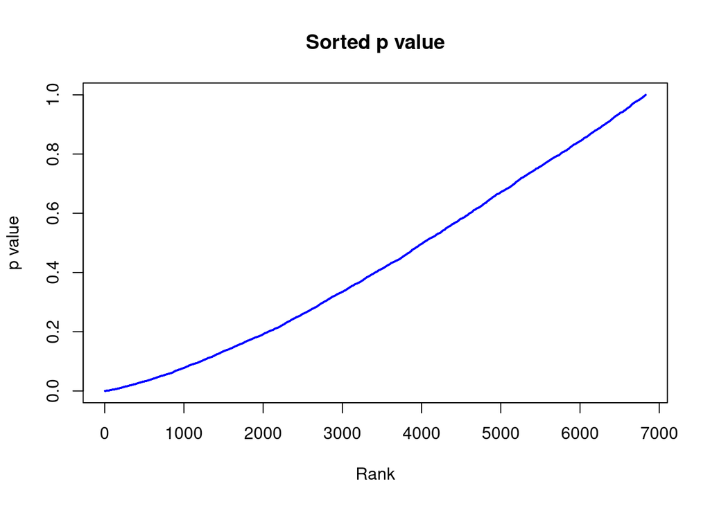

```r
NSCLC <- NCI60$data[NCI60$labs=='NSCLC',]
RENAL <- NCI60$data[NCI60$labs=='RENAL',]
p_values <- mapply(function(i)
  t.test(NSCLC[,i], RENAL[,i], var.equal = T,
         paired = F, alternative = "two.sided")$p.value,
  1:ncol(NSCLC))
sort_p <- sort(p_values)
plot(sort_p, xlab = "Rank", ylab = "p value",
     cex=0.1, col='blue', main = "Sorted p value")
```

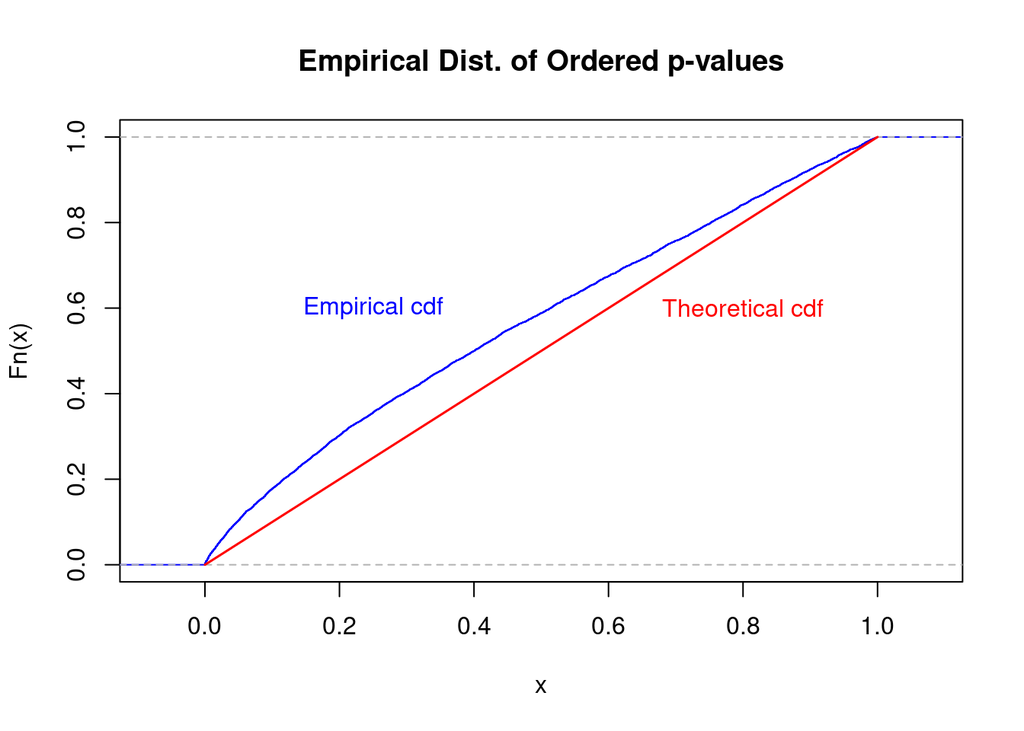

```r
plot(ecdf(sort_p), main="Empirical Dist. of Ordered p-values", col="blue")
lines(x=seq(0,1,0.01), y=seq(0,1,0.01), col="red", lwd=1.5)
text(0.8, 0.6, "Theoretical cdf", col="red")
text(0.25, 0.6, "Empirical cdf", col="blue")
```

```r
plot(sort_p, cex=0.5, xlim = c(1, 25), ylim = c(0, 0.0008),
     main = "FDR and FWER", xlab = 'index i', ylab = 'p-value', pch=8)
x <- c(1:6830); fdr <- c(x/6830*0.05); bonforroni <- rep(0.05 / 6830, times=length(x));
holm <- c(0.05/(length(x)-x+1))
sum(sort_p <= bonforroni[1])
```

```
## [1] 0
```

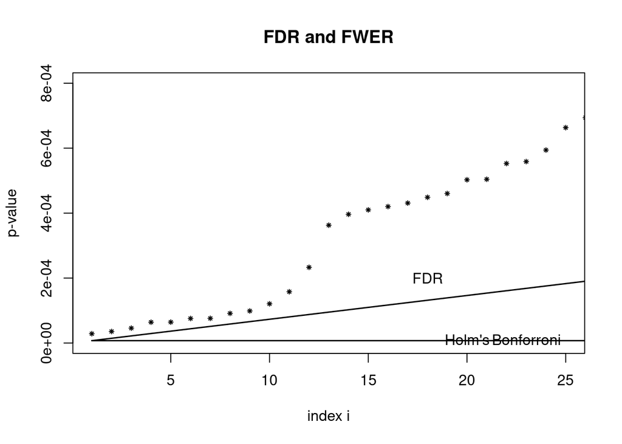

```r
lines(x, fdr,  lwd=1.5)
lines(x, bonforroni,  lwd=1.5)
lines(x, holm, lwd=0.5)
text(20, 0.00001, "Holm's")
text(23, 0.00001, "Bonforroni")
text(18, 0.0002, "FDR")
```

```r
 sum(p_values<=0.05)
```

```
## [1] 707
```

**Problem 2**

Use the NCI60 data, give an example to each of the following data analysis tasks (please refer to the Leek and Peng, Science (2015) articl). Note: this is an open question;diﬀerent people may give diﬀ erence examples to the same task.

**Solutions:**

1. Descriptive study In this dataset, there are 6830 columns and 64 rows.

**Solutions:**

2. Exploratory study Just calculate the genes’ mean

**Solutions:**

3. Inferential study Using different gene to get a SLM and see if there is any linear relationship.

**Solutions:**

4. Predictive study Use different model or plot to distinguish each gene.

**Solutions:**

5. Causal study Use different model or plot to see different between to genes.

**Solutions:**

6. Mechanistic study Use model or plot to see a genes experssion among other type.

```r
## Descriptive study
table(NCI60$labs)
```

```
##
##      BREAST         CNS       COLON K562A-repro K562B-repro    LEUKEMIA
##           7           5           7           1           1           6
## MCF7A-repro MCF7D-repro    MELANOMA       NSCLC     OVARIAN    PROSTATE
##           1           1           8           9           6           2
##       RENAL     UNKNOWN
##           9           1
```

[figure not shown]

```r
## Exploratory study
plot(round(apply(NCI60$data, 2, mean)[1:20], 4), xlab="Cell type",
     ylab="Gene expression",
     main="Exploratory of first 10 genes", pch=3)
```

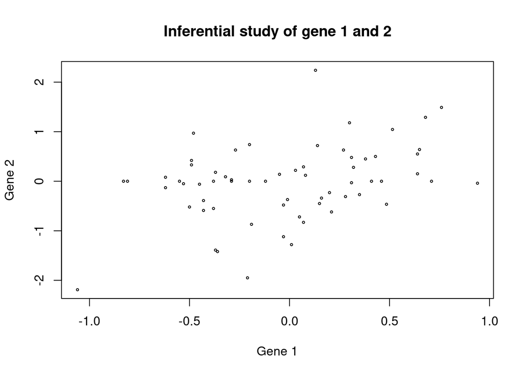

```r
## Inferential study
plot(NCI60$data[,1], NCI60$data[,2], xlab="Gene 1", ylab="Gene 2", cex=0.4,
     pch=1, main = "Inferential study of gene 1 and 2")
```

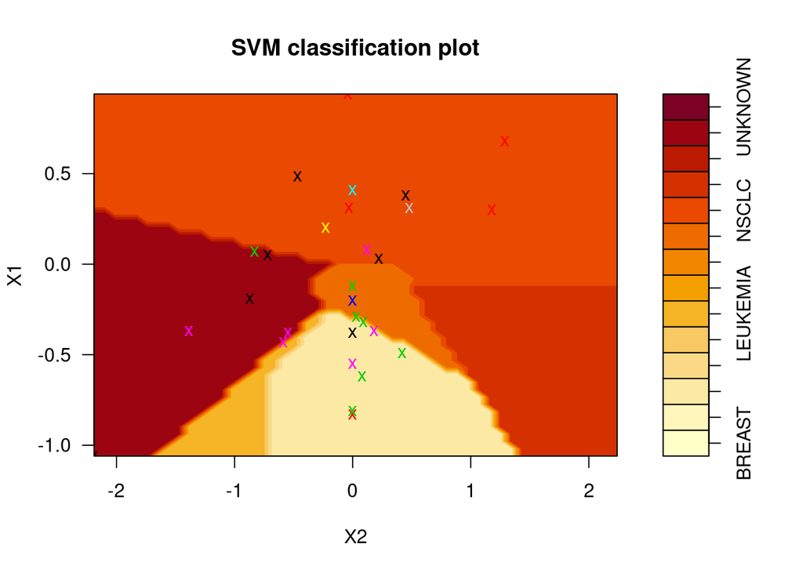

```r
## Predictive study
library(e1071)
dat <- data.frame(NCI60$data[,1:2], y=factor(NCI60$labs))
mod <- svm(y~., data=dat, kernel="linear", cost=10, scale = F)
plot(mod, dat)
```

**Problem 3**

**Solution:**

For 3.1 p-value is 0.116 For 3.2 p-value is 0.286

library(tidyverse)

```r
rm(list=ls())
babies <- read.table("babies.txt", header=TRUE)
bwt.nonsmoke <- subset(babies, smoke==0)$bwt
bwt.smoke <- subset(babies, smoke==1)$bwt

#1. We will generate the following statistics based on a sample size of 10 and observe the following diﬀerence:

permutation_test <- function(N=10, method='median', B=1000, randomseed=1) {

  n <- N
  set.seed(randomseed)
  nonsmokers <- sample(bwt.nonsmoke , n)
  smokers <- sample(bwt.smoke , n)
  if(method=='mean') {
    diff <- mean(smokers) - mean(nonsmokers)
  } else if(method=='median') diff <- median(smokers) - median(nonsmokers)
  else return("Choose between 'mean' and 'median' !")

 if(B > 100000) return("Iteration cannot be greater than 1000000 !")
  diff_permute <- c()
  for (i in 1:B) {
    dat <- c(smokers, nonsmokers)
    shuffle <- sample(dat)
    smokers_star <- shuffle[1:n]
    nonsmokers_star <- shuffle[(n+1):(2*n)]
    if(method=='mean') {
      diff_star <- mean(smokers_star) - mean(nonsmokers_star)
    } else if(method=='median') {
      diff_star <- median(smokers_star) - median(nonsmokers_star)
    }
    diff_permute <- c(diff_permute, diff_star)
  }
  p <- (sum(diff_permute <= -abs(diff)) + sum(diff_permute >= abs(diff))) / B
  return(list(test_statstic=diff, permutation=diff_permute, p_value=p))
}
result_mean <- permutation_test(N=10, method = 'mean', B=1000, randomseed=1)
result_mean$p_value
```

```
## [1] 0.116
```

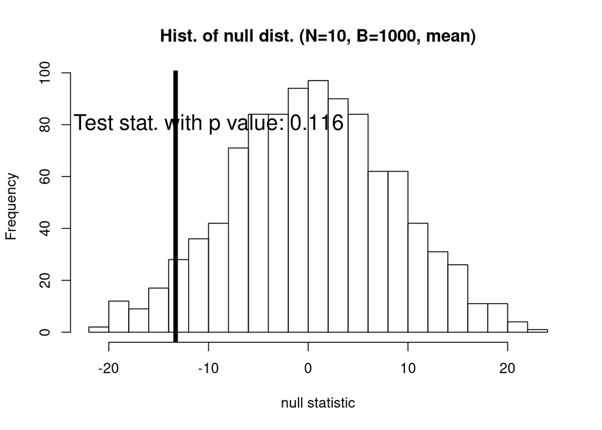

```r
hist(result_mean$permutation, breaks = 20,  xlab='null statistic',
     main = 'Hist. of null dist. (N=10, B=1000, mean)')
abline(v=result_mean$test_statstic, lwd=5)
text(-10, 80, paste("Test stat. with p value:", result_mean$p_value), cex=1.5)
```

```r
#2. Repeat the above exercise, but instead of the diﬀerences in mean, consider the diﬀerences in median.

result_med  <- permutation_test(N=10, method = 'median', B=1000, randomseed=1)
result_med$p_value
```

```
## [1] 0.286
```

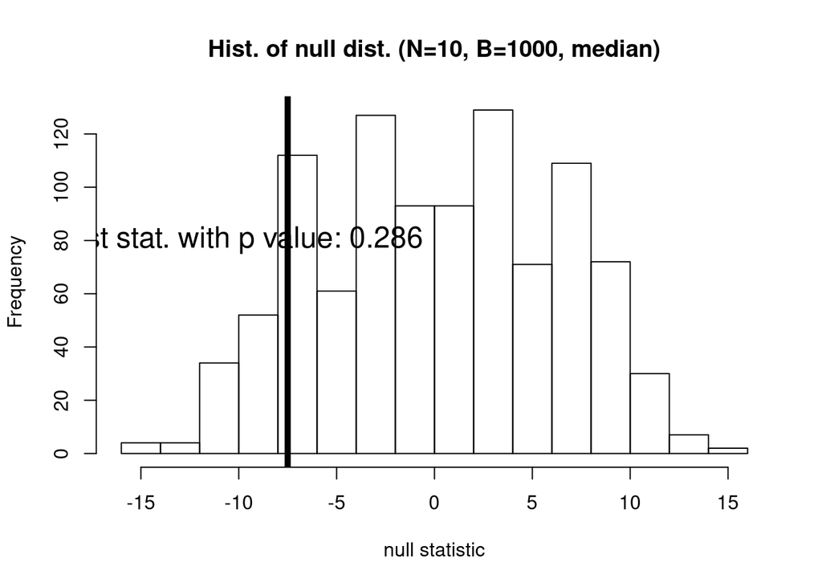

```r
hist(result_med$permutation, breaks = 20, xlab='null statistic',
     main = 'Hist. of null dist. (N=10, B=1000, median)')
abline(v=result_med$test_statstic, lwd=5)
text(-10, 80, paste("Test stat. with p value:", result_med$p_value), cex=1.5)
```

**Problem 4**

**Soluiton 4.1:** For smokers, the data is normal distributed. For non-smokers, the data is skewed.

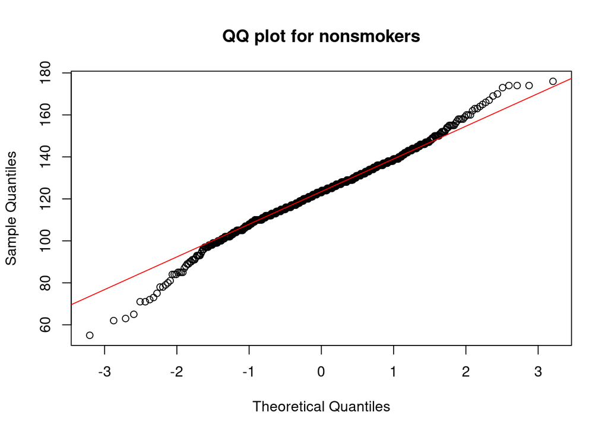

```r
#1. Please display the Q-Q plots and argue whether the Gaussian assumption is reasonable for this data set.

qqnorm(bwt.nonsmoke, main = "QQ plot for nonsmokers")
qqline(bwt.nonsmoke,col=2)
```

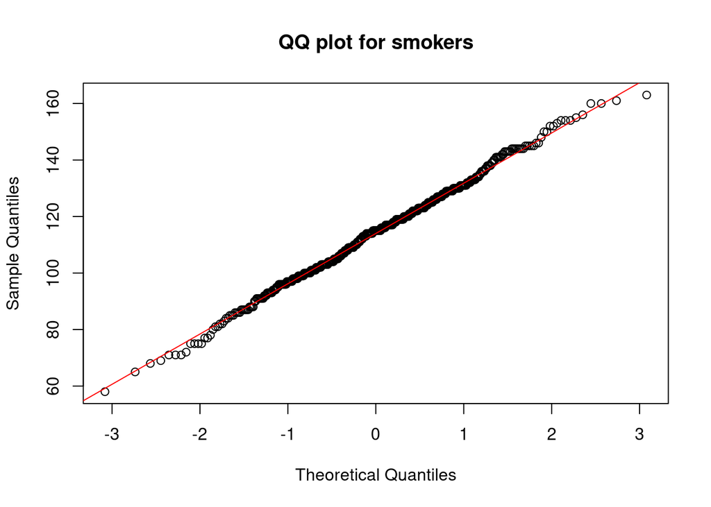

```r
qqnorm(bwt.smoke, main = "QQ plot for smokers")
qqline(bwt.smoke,col=2)
```

```r
#2. Perform the t test using the following R codes. Compare the resulting p-value with what you
# obtain from the permutation test in Problem 3. Do you reach the same conclusion?

n <- 10
nonsmokers <- sample(bwt.nonsmoke , n)
smokers <- sample(bwt.smoke , n)
result <- t.test(nonsmokers, smokers, alternative = 'two.sided')
result$p.value
```

```
## [1] 0.4494605
```

**Problem 5**

P = (0.99/3900)/((0.99/3900)+(0.01*3899/3900))=2.46%

**Problem 7**

Now increase n to 100. Repeat the above simulation, how does the distribution of the one million sample means change?

Now further increase n to 1000. Repeat the above simulation, how does the distribution of the one million sample means change?

What do we conclude about the distribution of the sample mean?

**Soluiton:** The distribution of simple mean will concertrate on a simple point.

**Soluiton:code for problem 7** dist_sample_mean <- function(sample_size=10, B=1000) { n <- sample_size x <- matrix(rnorm(n*B), ncol = B) hist(apply(x, 2, mean), breaks=100, freq=T, xlab=‘Sample mean’, main = paste(‘Hist. of sample mean (sample distribution) [ N=’, sample_size, ’]’)) }